# Linear Regression / Residuals

Sulalitha Bowala

### Linear Regression

Recall in Chapter 9 we investigated relationship between two variables using scatterplots and correlation coefficients. In this lab we wish to find the actual regression line that describes the linear relationship between the variable pairs.

Linear regression is a statistical method for modeling the relationship between a dependent variable (target) and one or more independent variables (predictors) by fitting a linear equation to the observed data. The goal is to find the best-fitting line (or hyperplane in the case of multiple predictors) that minimizes the sum of squared differences between the observed and predicted values.

To find the least squares regression equation between two variables in R, we use the function `lm` (which stands for linear model).

The R code used is `lm(y ~ x)` where `x` and `y` are your x- and y-variables. **Be very careful with the order!**

Key points about the lm function:

**Syntax**: lm(formula, data, …)

- formula: In the formula, the dependent variable is specified on the left side of the $\sim$ (tilde) symbol, and the independent variable(s) are listed on the right side. You can use + to include multiple independent variables. For example, $y \sim x_1 + x_2$ represents a multiple linear regression with two predictors.
- data: The data frame where the variables are located.

Example 1:

Recall in Chapter 9 we investigated the relationship between the Weight (1000 lbs) of cars (wt) and Miles/(US) gallon (mpg). The data are from `mtcars` dataset available in R.

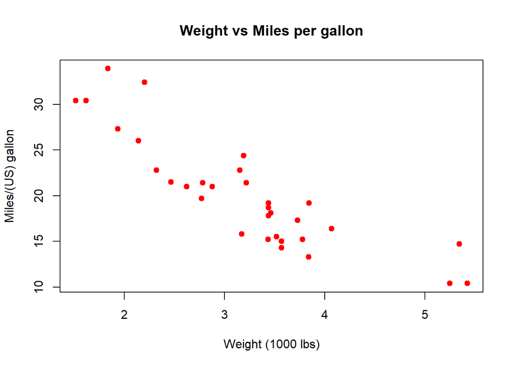

```r
x <- mtcars$wt
y <- mtcars$mpg

plot(x, y, main = "Weight vs Miles per gallon",
     xlab = "Weight (1000 lbs)", ylab = "Miles/(US) gallon",
     col = "red",
     pch = 19)
```

We can see that there is a noticeable downwards (negative) linear trend in the data.

Below we will find the least-squares regression equation for predicting Miles/(US) gallon (Y) from Weight (1000 lbs) of cars (X).

```r
lm(y ~ x)
```

```
##
## Call:
## lm(formula = y ~ x)
##
## Coefficients:
## (Intercept)            x
##      37.285       -5.344
```

We can see that the regression coefficients for this relationship is $\beta_0=37.285$ and $\beta_1=-5.344$.

In other words, we have the equation

$\hat{y} = 37.285 - 5.344*x$.

where $x$ = Weight (1000 lbs) of cars and $y$ = Miles/(US) gallon. In particular, we estimate that for every additional unit of weight (1000 lbs) of a car, reduce 5.344 in Miles/(US) gallon.

It is good practice to save the linear model as an object, as we can pull more information from it later. Below we will save these linear models as objects:

```r
lm.WeightVSMiles <- lm(y ~ x)
lm.WeightVSMiles
```

```
##
## Call:
## lm(formula = y ~ x)
##
## Coefficients:
## (Intercept)            x
##      37.285       -5.344
```

We can use these models to predict values of Y , for given values of X.

For example, the predicted Miles/(US) gallon for a car with a weight (1000 lbs) of a car 2.30.

```r
37.285 - 5.344*2.30
```

```
## [1] 24.9938
```

You can use the `summary` function on the model object to obtain detailed information about the regression, including coefficients, R-squared values, and more.

```r
summary(lm.WeightVSMiles)
```

```
##
## Call:
## lm(formula = y ~ x)
##
## Residuals:
##     Min      1Q  Median      3Q     Max
## -4.5432 -2.3647 -0.1252  1.4096  6.8727
##
## Coefficients:
##             Estimate Std. Error t value Pr(>|t|)
## (Intercept)  37.2851     1.8776  19.858  < 2e-16 ***
## x            -5.3445     0.5591  -9.559 1.29e-10 ***
## ---
## Signif. codes:  0 '***' 0.001 '**' 0.01 '*' 0.05 '.' 0.1 ' ' 1
##
## Residual standard error: 3.046 on 30 degrees of freedom
## Multiple R-squared:  0.7528, Adjusted R-squared:  0.7446
## F-statistic: 91.38 on 1 and 30 DF,  p-value: 1.294e-10
```

We can now also plot this regression line overtop of our scatterplots with the function `abline`.

The `abline` function in R is used to add straight lines to a plot. It’s often used to add reference lines, regression lines, or any straight line to a graphical plot created using functions like `plot`.

**Syntax**: abline(a = , b = , h = , v = , reg = , coef = , untf = , …)

- **h**: The y-coordinate for horizontal lines.
- **v**: The x-coordinate for vertical lines.
- **a and b**: The intercept and slope for diagonal lines. (Discuss in Unit 7)
- **col**: The color of the line.
- **lty**: The line type (lty = 1: Solid line (default), lty = 2: Dashed line, lty = 3: Dotted line, lty = 4: Dot-dash line, lty = 5: Long-dash line, lty = 6: Two dash-dot line, lty = 7: Two-dot line, lty = 8: Dash-dot-dot line).
- **lwd**: The line width.

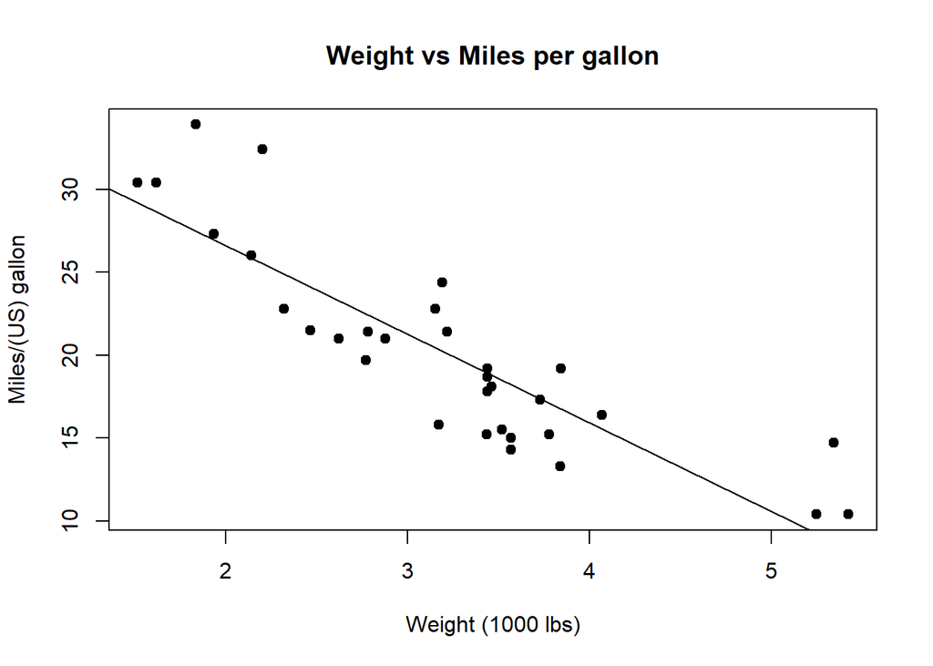

```r
plot(x, y, main = "Weight vs Miles per gallon",
     xlab = "Weight (1000 lbs)", ylab = "Miles/(US) gallon",
     pch = 19)
abline(lm.WeightVSMiles)
```

Note that this line is hard to see when we have more datapoints as it is a black line over top of black points. We can change the colour of the regression line with `col` and line width with `lwd`.

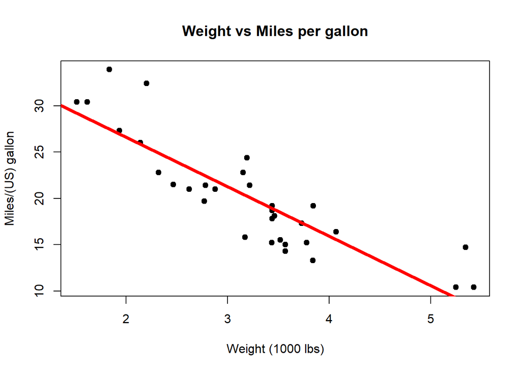

```r
plot(x, y, main = "Weight vs Miles per gallon",
     xlab = "Weight (1000 lbs)", ylab = "Miles/(US) gallon",
     pch = 19)
abline(lm.WeightVSMiles, col = "red", lwd = 4)
```

Also, we can use functions such as `grid()`, `abline(v = )` as a visual aids.

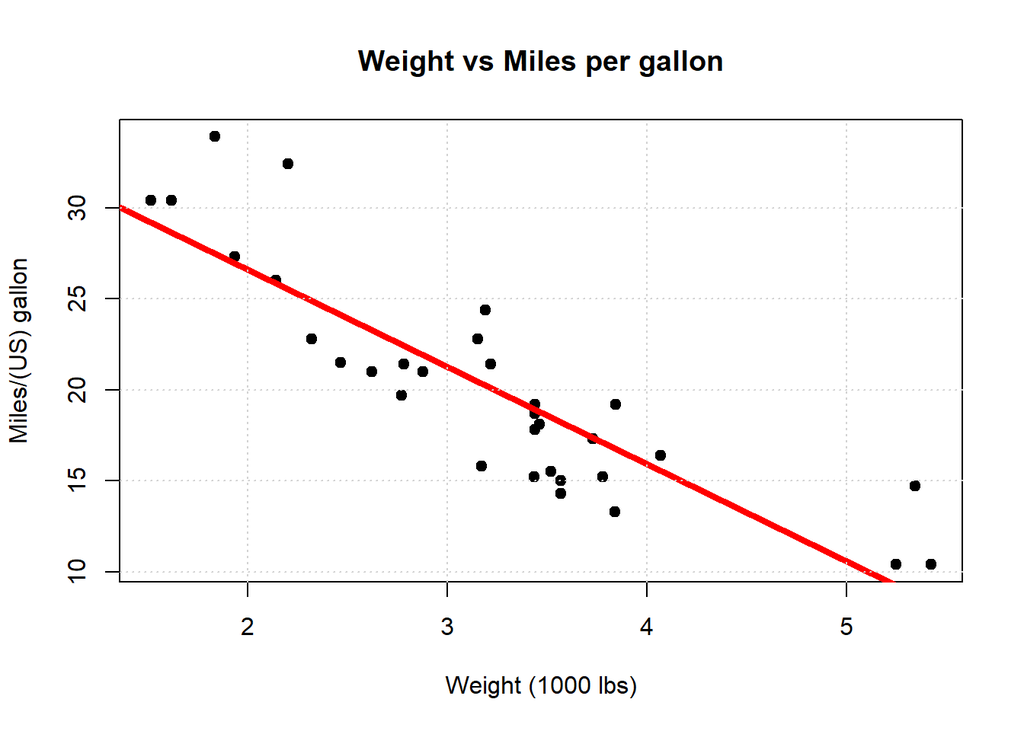

```r
plot(x, y, main = "Weight vs Miles per gallon",
     xlab = "Weight (1000 lbs)", ylab = "Miles/(US) gallon",
     pch = 19)
abline(lm.WeightVSMiles, col = "red", lwd = 4)
grid()
```

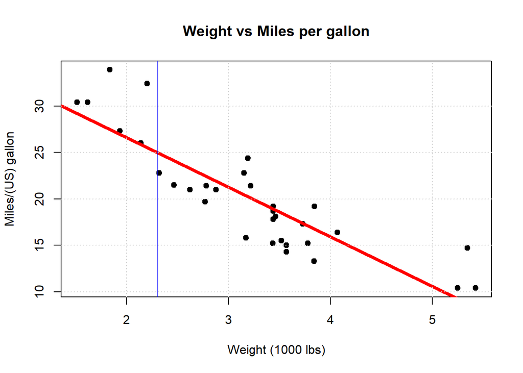

```r
plot(x, y, main = "Weight vs Miles per gallon",
     xlab = "Weight (1000 lbs)", ylab = "Miles/(US) gallon",
     pch = 19)
abline(lm.WeightVSMiles, col = "red", lwd = 4)
grid()
# weight (1000 lbs) of a car is 2.30.
abline(v=2.30, col="blue")
```

Example 2:

Here we investigate the linear relationship between weight and height of 12 students.

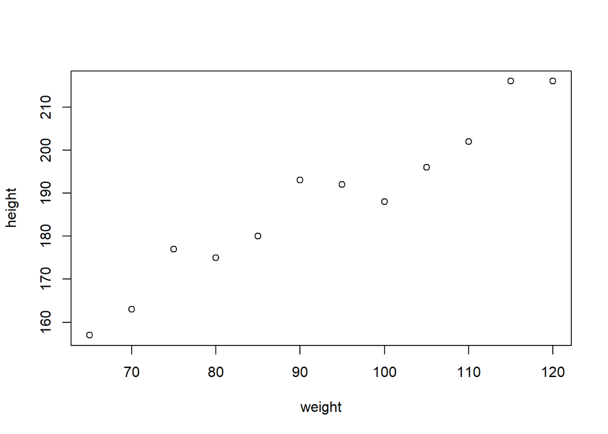

```r
# Sample data
weight <- c(65, 70, 75, 80, 85, 90, 95, 100, 105, 110, 115, 120)
height <- c(157, 163, 177, 175, 180, 193, 192, 188, 196, 202, 216, 216)

## Scatterplot
plot(weight, height)
```

```r
# Create a data frame
data <- data.frame(weight, height)

# Fit a simple linear regression model
model <- lm(height ~ weight, data = data)

# Summarize the model
summary(model)
```

```
##
## Call:
## lm(formula = height ~ weight, data = data)
##
## Residuals:
##     Min      1Q  Median      3Q     Max
## -7.4114 -3.4123 -0.4237  2.5886  7.5816
##
## Coefficients:
##             Estimate Std. Error t value Pr(>|t|)
## (Intercept) 95.48135    7.69232   12.41 2.12e-07 ***
## weight       0.99930    0.08175   12.22 2.45e-07 ***
## ---
## Signif. codes:  0 '***' 0.001 '**' 0.01 '*' 0.05 '.' 0.1 ' ' 1
##
## Residual standard error: 4.888 on 10 degrees of freedom
## Multiple R-squared:  0.9373, Adjusted R-squared:  0.931
## F-statistic: 149.4 on 1 and 10 DF,  p-value: 2.455e-07
```

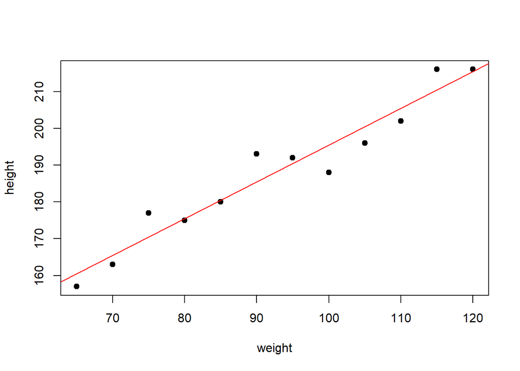

```r
# Print the regression line on top of the scatterplots
plot(weight, height, pch = 19)
abline(model, col="red")
```

### Residuals

With the `lm` function, we can also see the residuals of a scatterplot. All we have to do is use the `$residuals` suffix on the linear model object.

Below we will make a histogram of the residuals from the weight (1000 lbs) of a car vs. Miles/(US) gallon linear relationship.

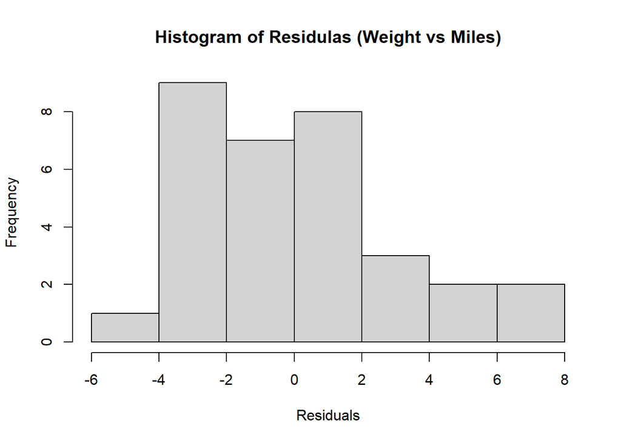

```r
hist(lm.WeightVSMiles$residuals,
     main = "Histogram of Residulas (Weight vs Miles)",
     xlab = "Residuals")
```